# Predicting Net Promoter Score for MHE

Group 7 (Yashika Girdhar, Suyash, Prateek, Shalini, R.M. Rama Chidambram, Paras Nasa, Sunil T Samuel)

### Overview & Data Clearning

**Problem Statement**

How to understand the customer concerns Via the NPS and improve certain area to give the best experience to the customers

**Analysis**

Analyze the following

1. How to improve the data quality and use it for NPS prediction
2. What are the significant factors influencing the detractors
3. What are the significant factors which contribute to improving the NPS
4. Find out the improvement opportunity within the depart using NPS score

**Data clearing**

```r
library(caret)
library(car)
library(dplyr)
```

```r
library(ggplot2)
library(fastDummies)
library(ROSE)
library(pROC)
```

*Import the complete data set to R*

```r
Complete_data<-read.csv("clipboard",sep = "\t",header = TRUE,stringsAsFactors = TRUE)
Hdata1<-Complete_data
```

*Data clearing*

```r
colSums(is.na(Hdata1))
```

```
##                    HospitalNo2                  MaritalStatus
##                              0                              0
##                         AgeYrs                            Sex
##                              0                              0
##                    BedCategory                     Department
##                              0                              0
##                  Estimatedcost               InsPayorcategory
##                              0                              0
##                          State                        Country
##                              0                              0
##                      STATEZONE               CE_ACCESSIBILITY
##                              0                              0
##                        CE_CSAT               CE_VALUEFORMONEY
##                              0                              0
##          EM_IMMEDIATEATTENTION                     EM_NURSING
##                              0                              0
##                      EM_DOCTOR                     EM_OVERALL
##                              0                              0
##                        AD_TIME AD_TARRIFFPACKAGESEXPLAINATION
##                              0                              0
##               AD_STAFFATTITUDE            INR_ROOMCLEANLINESS
##                              0                              0
##                  INR_ROOMPEACE              INR_ROOMEQUIPMENT
##                              0                              0
##               INR_ROOMAMBIENCE                FNB_FOODQUALITY
##                              0                              0
##           FNB_FOODDELIVERYTIME                  FNB_DIETICIAN
##                              0                              0
##              FNB_STAFFATTITUDE                AE_ATTENDEECARE
##                              0                              0
##           AE_PATIENTSTATUSINFO                AE_ATTENDEEFOOD
##                              0                              0
##      DOC_TREATMENTEXPLAINATION                   DOC_ATTITUDE
##                              0                              0
##                     DOC_VISITS     DOC_TREATMENTEFFECTIVENESS
##                              0                              0
##            NS_CALLBELLRESPONSE              NS_NURSESATTITUDE
##                              0                              0
##          NS_NURSEPROACTIVENESS               NS_NURSEPATIENCE
##                              0                              0
##       OVS_OVERALLSTAFFATTITUDE     OVS_OVERALLSTAFFPROMPTNESS
##                              0                              0
##           OVS_SECURITYATTITUDE               DP_DISCHARGETIME
##                              0                              0
##            DP_DISCHARGEQUERIES            DP_DISCHARGEPROCESS
##                              0                              0
##                  AdmissionDate                  DischargeDate
##                              0                              0
##                   LengthofStay                         CE_NPS
##                              0                              0
##                     NPS_Status
##                              0
```

```r
str(Hdata1)
```

```
## 'data.frame':    5353 obs. of  51 variables:
##  $ HospitalNo2                   : int  35236 35237 35234 35232 35233 35230 35231 73391 73462 35238 ...
##  $ MaritalStatus                 : Factor w/ 5 levels "Divorced","Married",..: 4 4 2 2 2 4 4 4 2 4 ...
##  $ AgeYrs                        : num  4 13 33 51 31 0.5 7 22 65 15 ...
##  $ Sex                           : Factor w/ 2 levels "F","M": 1 1 1 1 1 1 1 1 2 1 ...
##  $ BedCategory                   : Factor w/ 11 levels "CCU","DAYCARE",..: 9 9 7 9 9 7 9 3 9 7 ...
##  $ Department                    : Factor w/ 7 levels "CARDIOLOGY","GEN",..: 5 5 3 3 3 5 5 2 6 5 ...
##  $ Estimatedcost                 : num  25000 15000 70000 150000 100000 15000 50000 40000 150000 20000 ...
##  $ InsPayorcategory              : Factor w/ 5 levels "CORPORATE","EXEMPTION",..: 5 5 2 5 3 2 5 3 3 5 ...
##  $ State                         : Factor w/ 58 levels "Africa","Andaman And Nicobar",..: 21 21 21 57 21 21 21 21 21 21 ...
##  $ Country                       : Factor w/ 29 levels "Africa","ANGOLA",..: 7 7 7 7 7 7 7 7 7 7 ...
##  $ STATEZONE                     : Factor w/ 7 levels "CENTRAL","EAST",..: 5 5 5 2 5 5 5 5 5 5 ...
##  $ CE_ACCESSIBILITY              : int  4 4 3 4 4 4 3 4 4 4 ...
##  $ CE_CSAT                       : int  4 4 2 4 4 3 3 3 4 4 ...
##  $ CE_VALUEFORMONEY              : int  4 4 2 3 4 3 4 3 4 3 ...
```

[output cut: 37 more lines]

```r
Hdata1$NPS_Status<-as.factor(Hdata1$NPS_Status)
levels(Hdata1$NPS_Status)
```

```
## [1] "Detractor" "Promotor"
```

```r
Hdata1<-Hdata1[,-c(1,2,3,4,5,9:11,47,48,50)]
str(Hdata1)
```

```
## 'data.frame':    5353 obs. of  40 variables:
##  $ Department                    : Factor w/ 7 levels "CARDIOLOGY","GEN",..: 5 5 3 3 3 5 5 2 6 5 ...
##  $ Estimatedcost                 : num  25000 15000 70000 150000 100000 15000 50000 40000 150000 20000 ...
##  $ InsPayorcategory              : Factor w/ 5 levels "CORPORATE","EXEMPTION",..: 5 5 2 5 3 2 5 3 3 5 ...
##  $ CE_ACCESSIBILITY              : int  4 4 3 4 4 4 3 4 4 4 ...
##  $ CE_CSAT                       : int  4 4 2 4 4 3 3 3 4 4 ...
##  $ CE_VALUEFORMONEY              : int  4 4 2 3 4 3 4 3 4 3 ...
##  $ EM_IMMEDIATEATTENTION         : int  4 4 4 4 4 4 4 4 4 3 ...
##  $ EM_NURSING                    : int  4 4 4 4 4 4 4 4 4 4 ...
##  $ EM_DOCTOR                     : int  4 4 4 4 4 4 4 4 4 4 ...
##  $ EM_OVERALL                    : int  4 4 4 4 4 4 3 4 4 4 ...
##  $ AD_TIME                       : int  4 4 3 4 4 4 1 3 4 4 ...
##  $ AD_TARRIFFPACKAGESEXPLAINATION: int  4 4 3 4 4 4 2 3 4 4 ...
##  $ AD_STAFFATTITUDE              : int  4 4 4 4 4 4 2 4 4 4 ...
##  $ INR_ROOMCLEANLINESS           : int  4 4 3 3 4 4 3 3 4 3 ...
```

[output cut: 26 more lines]

### Logistic Regression

*Model using Logistic Regression*

```r
LRModel1<-glm(NPS_Status~.,data=Hdata1,family = "binomial")
summary(LRModel1)
```

```
##
## Call:
## glm(formula = NPS_Status ~ ., family = "binomial", data = Hdata1)
##
## Deviance Residuals:
##     Min       1Q   Median       3Q      Max
## -2.3500  -0.9032   0.4833   0.7949   2.4691
##
## Coefficients:
##                                  Estimate Std. Error z value Pr(>|z|)
## (Intercept)                    -7.814e+00  4.860e-01 -16.079  < 2e-16 ***
## DepartmentGEN                  -2.125e-01  1.474e-01  -1.442 0.149367
## DepartmentGYNAEC               -3.924e-01  1.821e-01  -2.155 0.031168 *
## DepartmentORTHO                 2.862e-02  1.820e-01   0.157 0.875082
## DepartmentPEDIATRIC            -4.817e-01  1.655e-01  -2.910 0.003609 **
## DepartmentRENAL                 2.488e-01  2.171e-01   1.146 0.251681
## DepartmentSPECIAL              -9.113e-02  1.586e-01  -0.575 0.565552
## Estimatedcost                  -6.973e-07  3.777e-07  -1.846 0.064852 .
## InsPayorcategoryEXEMPTION      -6.656e-02  1.717e-01  -0.388 0.698222
## InsPayorcategoryINSURANCE      -2.249e-01  1.346e-01  -1.672 0.094579 .
## InsPayorcategoryINTERNATIONAL   1.153e-01  3.247e-01   0.355 0.722443
## InsPayorcategoryPATIENT        -1.158e-01  1.328e-01  -0.872 0.383247
## CE_ACCESSIBILITY                7.528e-02  7.376e-02   1.021 0.307416
## CE_CSAT                         6.732e-01  8.163e-02   8.247  < 2e-16 ***
## CE_VALUEFORMONEY                5.763e-01  7.088e-02   8.131 4.25e-16 ***
## EM_IMMEDIATEATTENTION           1.462e-01  1.128e-01   1.296 0.194922
## EM_NURSING                      9.449e-02  1.357e-01   0.696 0.486275
## EM_DOCTOR                       1.272e-01  1.413e-01   0.901 0.367842
## EM_OVERALL                      8.305e-02  1.390e-01   0.597 0.550245
## AD_TIME                        -3.399e-03  6.933e-02  -0.049 0.960894
## AD_TARRIFFPACKAGESEXPLAINATION  3.789e-01  7.907e-02   4.792 1.65e-06 ***
## AD_STAFFATTITUDE               -2.529e-01  8.507e-02  -2.973 0.002953 **
## INR_ROOMCLEANLINESS            -1.724e-01  7.895e-02  -2.184 0.028956 *
## INR_ROOMPEACE                   6.379e-02  7.191e-02   0.887 0.374998
## INR_ROOMEQUIPMENT              -1.486e-01  8.614e-02  -1.725 0.084586 .
## INR_ROOMAMBIENCE                1.702e-01  9.695e-02   1.755 0.079186 .
## FNB_FOODQUALITY                 1.261e-01  6.440e-02   1.958 0.050270 .
## FNB_FOODDELIVERYTIME            1.829e-01  7.671e-02   2.384 0.017112 *
## FNB_DIETICIAN                   4.798e-02  8.056e-02   0.596 0.551455
## FNB_STAFFATTITUDE              -1.639e-01  8.985e-02  -1.824 0.068189 .
```

[output cut: 13 more lines]

```
## OVS_SECURITYATTITUDE           -1.943e-01  9.243e-02  -2.102 0.035516 *
## DP_DISCHARGETIME                1.305e-01  8.927e-02   1.461 0.143894
## DP_DISCHARGEQUERIES             2.170e-01  9.341e-02   2.323 0.020155 *
## DP_DISCHARGEPROCESS            -6.593e-02  1.102e-01  -0.598 0.549678
## LengthofStay                    9.814e-03  6.975e-03   1.407 0.159387
## ---
## Signif. codes:  0 '***' 0.001 '**' 0.01 '*' 0.05 '.' 0.1 ' ' 1
##
## (Dispersion parameter for binomial family taken to be 1)
##
##     Null deviance: 7085.4  on 5352  degrees of freedom
## Residual deviance: 5582.9  on 5305  degrees of freedom
## AIC: 5678.9
##
## Number of Fisher Scoring iterations: 4
```

```r
LRModel2<-step(LRModel1,trace = 0)
summary(LRModel2)
```

```
##
## Call:
## glm(formula = NPS_Status ~ Department + Estimatedcost + CE_CSAT +
##     CE_VALUEFORMONEY + EM_IMMEDIATEATTENTION + EM_DOCTOR + AD_TARRIFFPACKAGESEXPLAINATION +
##     AD_STAFFATTITUDE + INR_ROOMCLEANLINESS + INR_ROOMEQUIPMENT +
##     INR_ROOMAMBIENCE + FNB_FOODQUALITY + FNB_FOODDELIVERYTIME +
##     FNB_STAFFATTITUDE + AE_PATIENTSTATUSINFO + AE_ATTENDEEFOOD +
##     DOC_TREATMENTEXPLAINATION + DOC_VISITS + NS_NURSESATTITUDE +
##     OVS_OVERALLSTAFFPROMPTNESS + OVS_SECURITYATTITUDE + DP_DISCHARGETIME +
##     DP_DISCHARGEQUERIES + LengthofStay, family = "binomial",
##     data = Hdata1)
##
## Deviance Residuals:
##     Min       1Q   Median       3Q      Max
## -2.3418  -0.9129   0.4752   0.7943   2.4614
##
## Coefficients:
##                                  Estimate Std. Error z value Pr(>|z|)
## (Intercept)                    -7.939e+00  4.553e-01 -17.439  < 2e-16 ***
## DepartmentGEN                  -2.500e-01  1.379e-01  -1.814 0.069708 .
## DepartmentGYNAEC               -4.049e-01  1.808e-01  -2.240 0.025096 *
## DepartmentORTHO                -6.342e-03  1.765e-01  -0.036 0.971338
## DepartmentPEDIATRIC            -5.185e-01  1.571e-01  -3.300 0.000967 ***
## DepartmentRENAL                 2.097e-01  2.101e-01   0.998 0.318279
## DepartmentSPECIAL              -1.166e-01  1.534e-01  -0.760 0.447133
## Estimatedcost                  -6.321e-07  3.649e-07  -1.732 0.083223 .
## CE_CSAT                         7.060e-01  7.647e-02   9.232  < 2e-16 ***
## CE_VALUEFORMONEY                5.946e-01  6.924e-02   8.587  < 2e-16 ***
## EM_IMMEDIATEATTENTION           2.021e-01  9.779e-02   2.067 0.038721 *
## EM_DOCTOR                       2.264e-01  1.145e-01   1.977 0.048041 *
## AD_TARRIFFPACKAGESEXPLAINATION  3.751e-01  7.359e-02   5.097 3.45e-07 ***
## AD_STAFFATTITUDE               -2.451e-01  7.960e-02  -3.079 0.002074 **
## INR_ROOMCLEANLINESS            -1.579e-01  7.620e-02  -2.072 0.038228 *
## INR_ROOMEQUIPMENT              -1.300e-01  8.512e-02  -1.527 0.126773
## INR_ROOMAMBIENCE                1.994e-01  9.392e-02   2.123 0.033771 *
## FNB_FOODQUALITY                 1.346e-01  6.297e-02   2.137 0.032628 *
## FNB_FOODDELIVERYTIME            2.080e-01  7.355e-02   2.828 0.004680 **
## FNB_STAFFATTITUDE              -1.676e-01  8.459e-02  -1.981 0.047566 *
## AE_PATIENTSTATUSINFO            3.365e-01  8.681e-02   3.876 0.000106 ***
## AE_ATTENDEEFOOD                 1.102e-01  6.525e-02   1.689 0.091176 .
## DOC_TREATMENTEXPLAINATION      -3.191e-01  1.048e-01  -3.044 0.002333 **
## DOC_VISITS                      3.869e-01  9.706e-02   3.986 6.73e-05 ***
## NS_NURSESATTITUDE              -3.710e-01  1.003e-01  -3.701 0.000215 ***
## OVS_OVERALLSTAFFPROMPTNESS      3.757e-01  1.016e-01   3.700 0.000216 ***
## OVS_SECURITYATTITUDE           -1.895e-01  8.877e-02  -2.135 0.032768 *
## DP_DISCHARGETIME                1.047e-01  6.904e-02   1.517 0.129319
## DP_DISCHARGEQUERIES             2.044e-01  8.185e-02   2.498 0.012507 *
## LengthofStay                    1.043e-02  6.911e-03   1.510 0.131106
## ---
## Signif. codes:  0 '***' 0.001 '**' 0.01 '*' 0.05 '.' 0.1 ' ' 1
##
## (Dispersion parameter for binomial family taken to be 1)
##
##     Null deviance: 7085.4  on 5352  degrees of freedom
## Residual deviance: 5594.3  on 5323  degrees of freedom
## AIC: 5654.3
##
## Number of Fisher Scoring iterations: 4
```

*Split the data into Train and Test for building the prediction model*

```r
set.seed(1234)
Index<-createDataPartition(Hdata1$NPS_Status, p=.80, list=FALSE)
Train<-Hdata1[Index,]
Test<-Hdata1[-Index,]
prop.table(table(Hdata1$NPS_Status))
```

```
##
## Detractor  Promotor
## 0.3754904 0.6245096
```

```r
table(Hdata1$NPS_Status)
```

```
##
## Detractor  Promotor
##      2010      3343
```

```r
prop.table(table(Train$NPS_Status))
```

```
##
## Detractor  Promotor
## 0.3754378 0.6245622
```

```r
table(Train$NPS_Status)
```

```
##
## Detractor  Promotor
##      1608      2675
```

```r
prop.table(table(Test$NPS_Status))
```

```
##
## Detractor  Promotor
## 0.3757009 0.6242991
```

```r
table(Test$NPS_Status)
```

```
##
## Detractor  Promotor
##       402       668
```

*Build the prediction model using Train data*

```r
LRModelP1<-glm(NPS_Status~.,data = Train, family="binomial")
summary(LRModelP1)
```

```
##
## Call:
## glm(formula = NPS_Status ~ ., family = "binomial", data = Train)
##
## Deviance Residuals:
##     Min       1Q   Median       3Q      Max
## -2.3962  -0.9076   0.4877   0.7982   2.4169
##
## Coefficients:
##                                  Estimate Std. Error z value Pr(>|z|)
## (Intercept)                    -7.961e+00  5.430e-01 -14.660  < 2e-16 ***
## DepartmentGEN                  -1.248e-01  1.629e-01  -0.766 0.443641
## DepartmentGYNAEC               -3.210e-01  2.020e-01  -1.589 0.111959
## DepartmentORTHO                 7.015e-02  2.024e-01   0.347 0.728920
## DepartmentPEDIATRIC            -4.059e-01  1.829e-01  -2.220 0.026434 *
## DepartmentRENAL                 3.554e-01  2.456e-01   1.447 0.147913
## DepartmentSPECIAL              -4.721e-02  1.750e-01  -0.270 0.787330
## Estimatedcost                  -3.856e-07  4.369e-07  -0.883 0.377411
## InsPayorcategoryEXEMPTION       4.202e-02  1.911e-01   0.220 0.825917
## InsPayorcategoryINSURANCE      -1.992e-01  1.481e-01  -1.345 0.178566
## InsPayorcategoryINTERNATIONAL   2.753e-02  3.473e-01   0.079 0.936819
## InsPayorcategoryPATIENT        -6.696e-02  1.460e-01  -0.459 0.646447
## CE_ACCESSIBILITY               -2.268e-02  8.392e-02  -0.270 0.786948
## CE_CSAT                         7.202e-01  9.207e-02   7.822 5.19e-15 ***
## CE_VALUEFORMONEY                5.846e-01  7.938e-02   7.365 1.77e-13 ***
## EM_IMMEDIATEATTENTION           2.307e-01  1.255e-01   1.839 0.065979 .
## EM_NURSING                      1.468e-01  1.540e-01   0.954 0.340314
## EM_DOCTOR                       9.140e-02  1.592e-01   0.574 0.565965
## EM_OVERALL                      3.832e-02  1.546e-01   0.248 0.804200
## AD_TIME                         2.918e-02  7.825e-02   0.373 0.709251
## AD_TARRIFFPACKAGESEXPLAINATION  3.286e-01  8.829e-02   3.722 0.000198 ***
## AD_STAFFATTITUDE               -2.063e-01  9.520e-02  -2.167 0.030198 *
## INR_ROOMCLEANLINESS            -1.836e-01  8.798e-02  -2.087 0.036931 *
## INR_ROOMPEACE                   3.948e-02  8.003e-02   0.493 0.621787
## INR_ROOMEQUIPMENT              -5.950e-02  9.633e-02  -0.618 0.536774
## INR_ROOMAMBIENCE                1.204e-01  1.081e-01   1.114 0.265207
## FNB_FOODQUALITY                 1.499e-01  7.170e-02   2.091 0.036507 *
## FNB_FOODDELIVERYTIME            1.411e-01  8.513e-02   1.657 0.097465 .
## FNB_DIETICIAN                   6.373e-02  8.904e-02   0.716 0.474153
## FNB_STAFFATTITUDE              -1.620e-01  1.006e-01  -1.610 0.107431
```

[output cut: 13 more lines]

```
## OVS_SECURITYATTITUDE           -1.874e-01  1.024e-01  -1.829 0.067349 .
## DP_DISCHARGETIME                6.874e-02  9.916e-02   0.693 0.488155
## DP_DISCHARGEQUERIES             2.179e-01  1.049e-01   2.077 0.037823 *
## DP_DISCHARGEPROCESS            -2.262e-02  1.229e-01  -0.184 0.853980
## LengthofStay                    7.987e-03  7.913e-03   1.009 0.312844
## ---
## Signif. codes:  0 '***' 0.001 '**' 0.01 '*' 0.05 '.' 0.1 ' ' 1
##
## (Dispersion parameter for binomial family taken to be 1)
##
##     Null deviance: 5668.9  on 4282  degrees of freedom
## Residual deviance: 4481.5  on 4235  degrees of freedom
## AIC: 4577.5
##
## Number of Fisher Scoring iterations: 4
```

```r
LRModelP2<-step(LRModelP1,trace=0)
summary(LRModelP2)
```

```
##
## Call:
## glm(formula = NPS_Status ~ Department + CE_CSAT + CE_VALUEFORMONEY +
##     EM_IMMEDIATEATTENTION + EM_NURSING + AD_TARRIFFPACKAGESEXPLAINATION +
##     AD_STAFFATTITUDE + INR_ROOMCLEANLINESS + FNB_FOODQUALITY +
##     FNB_FOODDELIVERYTIME + FNB_STAFFATTITUDE + AE_PATIENTSTATUSINFO +
##     AE_ATTENDEEFOOD + DOC_TREATMENTEXPLAINATION + DOC_VISITS +
##     NS_NURSESATTITUDE + OVS_OVERALLSTAFFPROMPTNESS + OVS_SECURITYATTITUDE +
##     DP_DISCHARGEQUERIES, family = "binomial", data = Train)
##
## Deviance Residuals:
##     Min       1Q   Median       3Q      Max
## -2.3484  -0.9158   0.4740   0.8014   2.5850
##
## Coefficients:
##                                Estimate Std. Error z value Pr(>|z|)
## (Intercept)                    -8.08564    0.49280 -16.408  < 2e-16 ***
## DepartmentGEN                  -0.17784    0.14984  -1.187 0.235298
## DepartmentGYNAEC               -0.32920    0.19970  -1.648 0.099266 .
## DepartmentORTHO                -0.01652    0.19247  -0.086 0.931590
## DepartmentPEDIATRIC            -0.44421    0.17014  -2.611 0.009032 **
## DepartmentRENAL                 0.28782    0.23709   1.214 0.224754
## DepartmentSPECIAL              -0.07384    0.16740  -0.441 0.659122
## CE_CSAT                         0.73360    0.08557   8.573  < 2e-16 ***
## CE_VALUEFORMONEY                0.59971    0.07705   7.783 7.07e-15 ***
## EM_IMMEDIATEATTENTION           0.26122    0.10870   2.403 0.016253 *
## EM_NURSING                      0.22073    0.12262   1.800 0.071847 .
## AD_TARRIFFPACKAGESEXPLAINATION  0.35738    0.08202   4.357 1.32e-05 ***
## AD_STAFFATTITUDE               -0.20475    0.08812  -2.324 0.020152 *
## INR_ROOMCLEANLINESS            -0.13631    0.07071  -1.928 0.053893 .
## FNB_FOODQUALITY                 0.16374    0.06949   2.356 0.018463 *
## FNB_FOODDELIVERYTIME            0.17748    0.08113   2.188 0.028704 *
## FNB_STAFFATTITUDE              -0.17903    0.09349  -1.915 0.055498 .
## AE_PATIENTSTATUSINFO            0.34553    0.09595   3.601 0.000317 ***
## AE_ATTENDEEFOOD                 0.12704    0.07170   1.772 0.076425 .
## DOC_TREATMENTEXPLAINATION      -0.28850    0.11697  -2.466 0.013645 *
## DOC_VISITS                      0.35584    0.10935   3.254 0.001138 **
## NS_NURSESATTITUDE              -0.46842    0.11243  -4.166 3.09e-05 ***
## OVS_OVERALLSTAFFPROMPTNESS      0.44028    0.11278   3.904 9.46e-05 ***
## OVS_SECURITYATTITUDE           -0.18131    0.09819  -1.846 0.064821 .
## DP_DISCHARGEQUERIES             0.27400    0.07483   3.662 0.000251 ***
## ---
## Signif. codes:  0 '***' 0.001 '**' 0.01 '*' 0.05 '.' 0.1 ' ' 1
##
## (Dispersion parameter for binomial family taken to be 1)
##
##     Null deviance: 5668.9  on 4282  degrees of freedom
## Residual deviance: 4494.6  on 4258  degrees of freedom
## AIC: 4544.6
##
## Number of Fisher Scoring iterations: 4
```

*Evaluate the model using the test data*

```r
Predicted<-predict(LRModelP2, newdata = Test, type="response")
Test$Predicted<-Predicted
Test$Class<-ifelse(Test$Predicted>=0.5,1,0)
Test$Actual<-ifelse(Test$NPS_Status=="Promotor",1,0)
Test$Class<-as.factor(Test$Class)
Test$Actual<-factor(Test$Actual)
Test
```

|  | Department | Estimatedcost | InsPayorcategory | CE_ACCESSIBILITY | CE_CSAT | CE_VALUEFORMONEY | EM_IMMEDIATEATTENTION | EM_NURSING | EM_DOCTOR | EM_OVERALL | AD_TIME | AD_TARRIFFPACKAGESEXPLAINATION | AD_STAFFATTITUDE | INR_ROOMCLEANLINESS | INR_ROOMPEACE | INR_ROOMEQUIPMENT | INR_ROOMAMBIENCE | FNB_FOODQUALITY | FNB_FOODDELIVERYTIME | FNB_DIETICIAN | FNB_STAFFATTITUDE | AE_ATTENDEECARE | AE_PATIENTSTATUSINFO | AE_ATTENDEEFOOD | DOC_TREATMENTEXPLAINATION | DOC_ATTITUDE | DOC_VISITS | DOC_TREATMENTEFFECTIVENESS | NS_CALLBELLRESPONSE | … |
| --- | --- | --- | --- | --- | --- | --- | --- | --- | --- | --- | --- | --- | --- | --- | --- | --- | --- | --- | --- | --- | --- | --- | --- | --- | --- | --- | --- | --- | --- | --- |
| 3 | GYNAEC | 70000 | EXEMPTION | 3 | 2 | 2 | 4 | 4 | 4 | 4 | 3 | 3 | 4 | 3 | 3 | 3 | 3 | 2 | 3 | 3 | 4 | 4 | 4 | 3 | 4 | 4 | 4 | 4 | 4 | … |
| 7 | PEDIATRIC | 50000 | PATIENT | 3 | 3 | 4 | 4 | 4 | 4 | 3 | 1 | 2 | 2 | 3 | 4 | 3 | 3 | 3 | 3 | 4 | 4 | 4 | 4 | 4 | 4 | 4 | 4 | 4 | 4 | … |
| 13 | PEDIATRIC | 75000 | PATIENT | 3 | 3 | 3 | 4 | 4 | 4 | 4 | 3 | 3 | 3 | 3 | 3 | 3 | 3 | 3 | 2 | 3 | 4 | 3 | 3 | 3 | 2 | 3 | 2 | 3 | 3 | … |
| 16 | SPECIAL | 70000 | PATIENT | 4 | 4 | 3 | 4 | 4 | 4 | 4 | 3 | 4 | 4 | 4 | 4 | 4 | 4 | 4 | 4 | 4 | 4 | 4 | 4 | 4 | 4 | 4 | 4 | 4 | 4 | … |
| 24 | RENAL | 130000 | INSURANCE | 4 | 3 | 3 | 4 | 4 | 4 | 4 | 4 | 3 | 4 | 4 | 3 | 4 | 3 | 3 | 3 | 4 | 4 | 4 | 4 | 3 | 4 | 4 | 4 | 4 | 4 | … |
| 26 | SPECIAL | 280000 | INSURANCE | 3 | 4 | 3 | 4 | 4 | 4 | 4 | 2 | 2 | 2 | 3 | 3 | 3 | 3 | 1 | 3 | 2 | 3 | 3 | 3 | 1 | 4 | 3 | 3 | 4 | 4 | … |
| 29 | GEN | 35000 | INSURANCE | 4 | 4 | 4 | 4 | 4 | 4 | 4 | 4 | 4 | 4 | 4 | 4 | 4 | 4 | 4 | 4 | 4 | 4 | 4 | 4 | 4 | 4 | 4 | 4 | 4 | 4 | … |
| 33 | SPECIAL | 30000 | INSURANCE | 3 | 2 | 2 | 4 | 4 | 4 | 4 | 2 | 2 | 3 | 3 | 3 | 3 | 3 | 3 | 3 | 3 | 3 | 3 | 3 | 3 | 4 | 4 | 3 | 3 | 4 | … |
| 35 | ORTHO | 75000 | INSURANCE | 4 | 4 | 4 | 4 | 4 | 4 | 4 | 4 | 4 | 4 | 4 | 4 | 4 | 4 | 3 | 4 | 3 | 4 | 4 | 4 | 4 | 4 | 4 | 4 | 4 | 4 | … |
| 40 | CARDIOLOGY | 250000 | EXEMPTION | 4 | 3 | 3 | 4 | 4 | 4 | 4 | 4 | 3 | 3 | 3 | 3 | 3 | 3 | 3 | 4 | 4 | 4 | 4 | 3 | 3 | 4 | 4 | 3 | 4 | 3 | … |

[output cut: 1060 more lines]

*Find the sensitivity and specificity*

```r
confusionMatrix(Test$Class, Test$Actual,positive = "1")
```

```
## Confusion Matrix and Statistics
##
##           Reference
## Prediction   0   1
##          0 243  92
##          1 159 576
##
##                Accuracy : 0.7654
##                  95% CI : (0.7389, 0.7905)
##     No Information Rate : 0.6243
##     P-Value [Acc > NIR] : < 2.2e-16
##
##                   Kappa : 0.4828
##
##  Mcnemar's Test P-Value : 3.101e-05
##
##             Sensitivity : 0.8623
##             Specificity : 0.6045
##          Pos Pred Value : 0.7837
##          Neg Pred Value : 0.7254
##              Prevalence : 0.6243
##          Detection Rate : 0.5383
##    Detection Prevalence : 0.6869
##       Balanced Accuracy : 0.7334
##
##        'Positive' Class : 1
##
```

*Check the Precision, rcall and accuracy to check the data imbalance*

```r
accuracy.meas(Test$NPS_Status,Predicted)
```

```
##
## Call:
## accuracy.meas(response = Test$NPS_Status, predicted = Predicted)
##
## Examples are labelled as positive when predicted is greater than 0.5
##
## precision: 0.784
## recall: 0.862
## F: 0.411
```

*Find ROC and AUC*

```r
par(pty="s")
roc(Test$Actual,Predicted, plot=TRUE, print.auc=TRUE,legacy.axes=TRUE, percent=TRUE, xlab="False Positive Percentage",ylab="True Positive Percentage", col="#de2d26",lwd=4)
```

```
##
## Call:
## roc.default(response = Test$Actual, predictor = Predicted, percent = TRUE,     plot = TRUE, print.auc = TRUE, legacy.axes = TRUE, xlab = "False Positive Percentage",     ylab = "True Positive Percentage", col = "#de2d26", lwd = 4)
##
## Data: Predicted in 402 controls (Test$Actual 0) < 668 cases (Test$Actual 1).
## Area under the curve: 79.6%
```

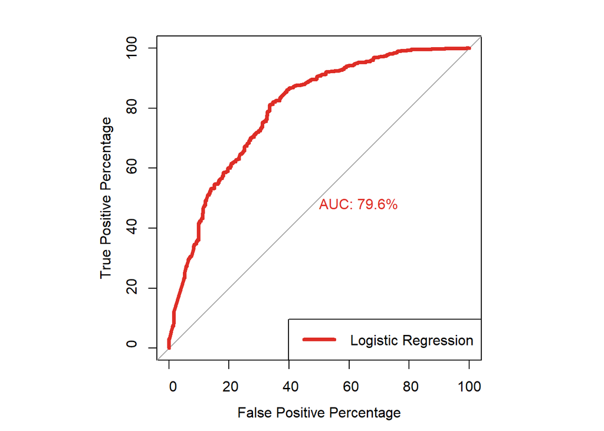

```r
legend("bottomright", legend = "Logistic Regression", col="#de2d26",lwd=4)
```

*Create the data frame with TPP, FPP and Threshold*

```r
roc.info<-roc(Test$Actual,Predicted, legacy.axes=TRUE)
roc.df<-data.frame(TPP=roc.info$sensitivities*100,FPP=(1-roc.info$specificities)*100,Threshold=roc.info$thresholds)
roc.df
```

| TPP | FPP | Threshold |
| --- | --- | --- |
| 100.0000000 | 100.0000000 | -Inf |
| 100.0000000 | 99.7512438 | 0.007352171 |
| 100.0000000 | 99.5024876 | 0.008470234 |
| 100.0000000 | 99.2537313 | 0.010153906 |
| 100.0000000 | 99.0049751 | 0.012244808 |
| 99.8502994 | 99.0049751 | 0.013446815 |
| 99.8502994 | 98.7562189 | 0.016798275 |
| 99.8502994 | 98.5074627 | 0.023022550 |
| 99.8502994 | 98.2587065 | 0.028703715 |
| 99.8502994 | 98.0099502 | 0.033770122 |

[output cut: 743 more lines]

### Decesion Tree

*Libraries used for Decision Tree*

```r
library(caTools)
library(party)
library(magrittr)
```

*Import data into R*

```r
Ddata1<-Complete_data
Ddata1<-Ddata1[,-c(1,2,3,4,5,9:11,47,48,50)]
str(Ddata1)
```

```
## 'data.frame':    5353 obs. of  40 variables:
##  $ Department                    : Factor w/ 7 levels "CARDIOLOGY","GEN",..: 5 5 3 3 3 5 5 2 6 5 ...
##  $ Estimatedcost                 : num  25000 15000 70000 150000 100000 15000 50000 40000 150000 20000 ...
##  $ InsPayorcategory              : Factor w/ 5 levels "CORPORATE","EXEMPTION",..: 5 5 2 5 3 2 5 3 3 5 ...
##  $ CE_ACCESSIBILITY              : int  4 4 3 4 4 4 3 4 4 4 ...
##  $ CE_CSAT                       : int  4 4 2 4 4 3 3 3 4 4 ...
##  $ CE_VALUEFORMONEY              : int  4 4 2 3 4 3 4 3 4 3 ...
##  $ EM_IMMEDIATEATTENTION         : int  4 4 4 4 4 4 4 4 4 3 ...
##  $ EM_NURSING                    : int  4 4 4 4 4 4 4 4 4 4 ...
##  $ EM_DOCTOR                     : int  4 4 4 4 4 4 4 4 4 4 ...
##  $ EM_OVERALL                    : int  4 4 4 4 4 4 3 4 4 4 ...
##  $ AD_TIME                       : int  4 4 3 4 4 4 1 3 4 4 ...
##  $ AD_TARRIFFPACKAGESEXPLAINATION: int  4 4 3 4 4 4 2 3 4 4 ...
##  $ AD_STAFFATTITUDE              : int  4 4 4 4 4 4 2 4 4 4 ...
##  $ INR_ROOMCLEANLINESS           : int  4 4 3 3 4 4 3 3 4 3 ...
```

[output cut: 26 more lines]

```r
Ddata1$NPS_Status<-as.factor(Ddata1$NPS_Status)
```

*Split the data into test and train*

```r
set.seed(1234)
DIndex<-sample.split(Ddata1, SplitRatio = 0.8)
DTrain<-subset(Ddata1,DIndex==TRUE)
DTest<-subset(Ddata1,DIndex==FALSE)
table(DTrain$NPS_Status)
```

```
##
## Detractor  Promotor
##      1616      2667
```

```r
table(DTest$NPS_Status)
```

```
##
## Detractor  Promotor
##       394       676
```

*Build the Model using train data*

[figure not shown]

```r
Dmodel<-ctree(NPS_Status~.,DTrain)
plot(Dmodel)
```

```r
print(Dmodel)
```

```
##
##   Conditional inference tree with 18 terminal nodes
##
## Response:  NPS_Status
## Inputs:  Department, Estimatedcost, InsPayorcategory, CE_ACCESSIBILITY, CE_CSAT, CE_VALUEFORMONEY, EM_IMMEDIATEATTENTION, EM_NURSING, EM_DOCTOR, EM_OVERALL, AD_TIME, AD_TARRIFFPACKAGESEXPLAINATION, AD_STAFFATTITUDE, INR_ROOMCLEANLINESS, INR_ROOMPEACE, INR_ROOMEQUIPMENT, INR_ROOMAMBIENCE, FNB_FOOD…
## Number of observations:  4283
##
## 1) CE_CSAT <= 3; criterion = 1, statistic = 706.553
##   2) CE_VALUEFORMONEY <= 2; criterion = 1, statistic = 175.616
##     3) DOC_VISITS <= 3; criterion = 0.999, statistic = 17.613
##       4)*  weights = 217
##     3) DOC_VISITS > 3
##       5) INR_ROOMPEACE <= 3; criterion = 0.954, statistic = 10.483
##         6)*  weights = 72
##       5) INR_ROOMPEACE > 3
##         7)*  weights = 22
##   2) CE_VALUEFORMONEY > 2
##     8) AE_ATTENDEEFOOD <= 2; criterion = 1, statistic = 68.521
##       9) DOC_VISITS <= 2; criterion = 0.988, statistic = 12.945
##         10)*  weights = 24
##       9) DOC_VISITS > 2
##         11)*  weights = 269
##     8) AE_ATTENDEEFOOD > 2
##       12) DP_DISCHARGETIME <= 2; criterion = 1, statistic = 47.232
##         13)*  weights = 134
##       12) DP_DISCHARGETIME > 2
##         14) FNB_FOODQUALITY <= 2; criterion = 1, statistic = 25.467
##           15)*  weights = 122
##         14) FNB_FOODQUALITY > 2
##           16) AD_TARRIFFPACKAGESEXPLAINATION <= 2; criterion = 1, statistic = 26.182
##             17)*  weights = 56
##           16) AD_TARRIFFPACKAGESEXPLAINATION > 2
##             18) INR_ROOMCLEANLINESS <= 3; criterion = 0.999, statistic = 18.228
##               19)*  weights = 629
##             18) INR_ROOMCLEANLINESS > 3
##               20) DP_DISCHARGEPROCESS <= 3; criterion = 1, statistic = 55.977
##                 21) AE_ATTENDEEFOOD <= 3; criterion = 0.998, statistic = 16.687
##                   22)*  weights = 214
##                 21) AE_ATTENDEEFOOD > 3
##                   23)*  weights = 30
##               20) DP_DISCHARGEPROCESS > 3
##                 24)*  weights = 194
## 1) CE_CSAT > 3
##   25) FNB_DIETICIAN <= 3; criterion = 1, statistic = 71.015
##     26) AD_TARRIFFPACKAGESEXPLAINATION <= 3; criterion = 0.994, statistic = 14.456
##       27)*  weights = 602
##     26) AD_TARRIFFPACKAGESEXPLAINATION > 3
##       28)*  weights = 380
##   25) FNB_DIETICIAN > 3
##     29) CE_ACCESSIBILITY <= 3; criterion = 1, statistic = 37.937
##       30)*  weights = 68
##     29) CE_ACCESSIBILITY > 3
##       31) DOC_TREATMENTEFFECTIVENESS <= 3; criterion = 1, statistic = 19.333
##         32)*  weights = 38
##       31) DOC_TREATMENTEFFECTIVENESS > 3
##         33) CE_VALUEFORMONEY <= 3; criterion = 0.976, statistic = 13.445
##           34)*  weights = 200
##         33) CE_VALUEFORMONEY > 3
##           35)*  weights = 1012
```

*Evaluate the model using test data*

```r
PredictD<-predict(Dmodel,DTest)
DTest$Actual<-ifelse(DTest$NPS_Status=="Promotor",1,0)
DTest$Actual<-as.factor(DTest$Actual)
DTest$Predicted<-PredictD
DTest$Pre_Value<-ifelse(DTest$Predicted=="Promotor",1,0)
DTest$Predicted<-as.factor(DTest$Predicted)
DTest
```

|  | Department | Estimatedcost | InsPayorcategory | CE_ACCESSIBILITY | CE_CSAT | CE_VALUEFORMONEY | EM_IMMEDIATEATTENTION | EM_NURSING | EM_DOCTOR | EM_OVERALL | AD_TIME | AD_TARRIFFPACKAGESEXPLAINATION | AD_STAFFATTITUDE | INR_ROOMCLEANLINESS | INR_ROOMPEACE | INR_ROOMEQUIPMENT | INR_ROOMAMBIENCE | FNB_FOODQUALITY | FNB_FOODDELIVERYTIME | FNB_DIETICIAN | FNB_STAFFATTITUDE | AE_ATTENDEECARE | AE_PATIENTSTATUSINFO | AE_ATTENDEEFOOD | DOC_TREATMENTEXPLAINATION | DOC_ATTITUDE | DOC_VISITS | DOC_TREATMENTEFFECTIVENESS | NS_CALLBELLRESPONSE | … |
| --- | --- | --- | --- | --- | --- | --- | --- | --- | --- | --- | --- | --- | --- | --- | --- | --- | --- | --- | --- | --- | --- | --- | --- | --- | --- | --- | --- | --- | --- | --- |
| 5 | GYNAEC | 100000.00 | INSURANCE | 4 | 4 | 4 | 4 | 4 | 4 | 4 | 4 | 4 | 4 | 4 | 4 | 4 | 4 | 4 | 4 | 4 | 4 | 4 | 4 | 4 | 4 | 4 | 4 | 4 | 4 | … |
| 14 | GEN | 40000.00 | INSURANCE | 4 | 3 | 3 | 3 | 3 | 3 | 3 | 3 | 3 | 3 | 3 | 3 | 2 | 3 | 3 | 3 | 2 | 3 | 3 | 3 | 2 | 3 | 3 | 3 | 3 | 3 | … |
| 16 | SPECIAL | 70000.00 | PATIENT | 4 | 4 | 3 | 4 | 4 | 4 | 4 | 3 | 4 | 4 | 4 | 4 | 4 | 4 | 4 | 4 | 4 | 4 | 4 | 4 | 4 | 4 | 4 | 4 | 4 | 4 | … |
| 26 | SPECIAL | 280000.00 | INSURANCE | 3 | 4 | 3 | 4 | 4 | 4 | 4 | 2 | 2 | 2 | 3 | 3 | 3 | 3 | 1 | 3 | 2 | 3 | 3 | 3 | 1 | 4 | 3 | 3 | 4 | 4 | … |
| 28 | GEN | 60000.00 | PATIENT | 3 | 3 | 3 | 4 | 4 | 4 | 4 | 3 | 3 | 3 | 3 | 3 | 3 | 3 | 3 | 3 | 3 | 3 | 3 | 3 | 3 | 3 | 3 | 3 | 3 | 3 | … |
| 29 | GEN | 35000.00 | INSURANCE | 4 | 4 | 4 | 4 | 4 | 4 | 4 | 4 | 4 | 4 | 4 | 4 | 4 | 4 | 4 | 4 | 4 | 4 | 4 | 4 | 4 | 4 | 4 | 4 | 4 | 4 | … |
| 39 | GEN | 30000.00 | PATIENT | 4 | 3 | 3 | 3 | 3 | 3 | 3 | 1 | 2 | 2 | 4 | 4 | 4 | 4 | 2 | 3 | 2 | 3 | 3 | 3 | 2 | 3 | 3 | 3 | 3 | 3 | … |
| 40 | CARDIOLOGY | 250000.00 | EXEMPTION | 4 | 3 | 3 | 4 | 4 | 4 | 4 | 4 | 3 | 3 | 3 | 3 | 3 | 3 | 3 | 4 | 4 | 4 | 4 | 3 | 3 | 4 | 4 | 3 | 4 | 3 | … |
| 45 | GEN | 40000.00 | PATIENT | 4 | 4 | 4 | 4 | 4 | 4 | 4 | 4 | 4 | 4 | 4 | 4 | 4 | 4 | 4 | 4 | 4 | 4 | 4 | 4 | 4 | 4 | 4 | 4 | 4 | 4 | … |
| 54 | RENAL | 100000.00 | PATIENT | 4 | 4 | 3 | 4 | 4 | 4 | 4 | 2 | 2 | 2 | 4 | 4 | 4 | 4 | 3 | 4 | 4 | 4 | 4 | 4 | 3 | 4 | 4 | 4 | 4 | 4 | … |

[output cut: 1060 more lines]

*Create the confusion matrix*

```r
confusionMatrix(DTest$NPS_Status,PredictD)
```

```
## Confusion Matrix and Statistics
##
##            Reference
## Prediction  Detractor Promotor
##   Detractor       198      196
##   Promotor         74      602
##
##                Accuracy : 0.7477
##                  95% CI : (0.7205, 0.7734)
##     No Information Rate : 0.7458
##     P-Value [Acc > NIR] : 0.4603
##
##                   Kappa : 0.4202
##
##  Mcnemar's Test P-Value : 1.787e-13
##
##             Sensitivity : 0.7279
##             Specificity : 0.7544
##          Pos Pred Value : 0.5025
##          Neg Pred Value : 0.8905
##              Prevalence : 0.2542
##          Detection Rate : 0.1850
##    Detection Prevalence : 0.3682
##       Balanced Accuracy : 0.7412
##
##        'Positive' Class : Detractor
##
```

*Compare ROC and AUC for logistic regression and Decision tree*

```r
par(pty="s")
roc(Test$Actual,Predicted, plot=TRUE, print.auc=TRUE,legacy.axes=TRUE, percent=TRUE, xlab="False Positive Percentage",
    ylab="True Positive Percentage", col="#de2d26",lwd=4)
```

```
##
## Call:
## roc.default(response = Test$Actual, predictor = Predicted, percent = TRUE,     plot = TRUE, print.auc = TRUE, legacy.axes = TRUE, xlab = "False Positive Percentage",     ylab = "True Positive Percentage", col = "#de2d26", lwd = 4)
##
## Data: Predicted in 402 controls (Test$Actual 0) < 668 cases (Test$Actual 1).
## Area under the curve: 79.6%
```

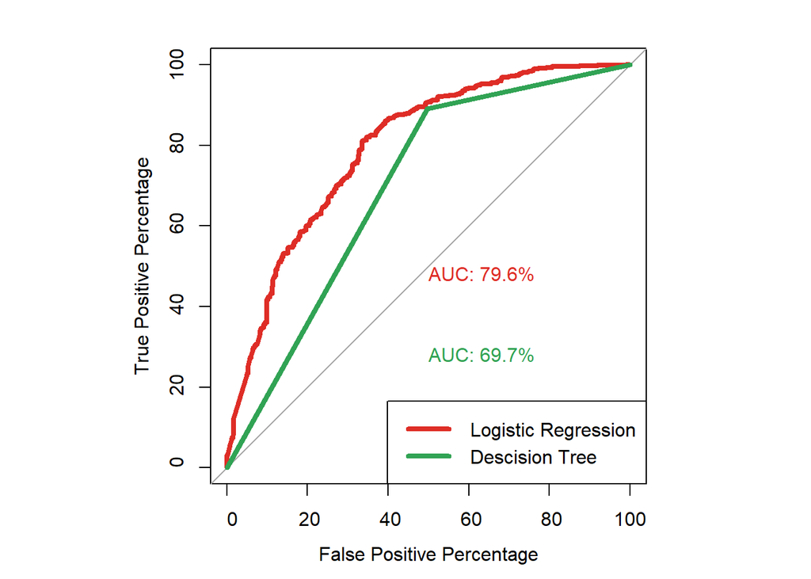

```r
plot.roc(DTest$Actual, DTest$Pre_Value, percent=TRUE, col="#31a354", lwd=4, print.auc=TRUE, add=TRUE, print.auc.y=30)
legend("bottomright", legend = c("Logistic Regression", "Descision Tree"), col=c("#de2d26","#31a354"),lwd=4)
```

### Random Forest

*Libraries used*

```r
library(caTools)
library(party)
library(magrittr)
library(rpart)
```

```r
library(rpart.plot)
library(RColorBrewer)
library(rattle)
library(randomForest)
```

*Import data in R*

```r
Rdata1<-Complete_data
Rdata1<-Rdata1[,-c(1,2,3,4,5,9:11,47,48,50)]
str(Rdata1)
```

```
## 'data.frame':    5353 obs. of  40 variables:
##  $ Department                    : Factor w/ 7 levels "CARDIOLOGY","GEN",..: 5 5 3 3 3 5 5 2 6 5 ...
##  $ Estimatedcost                 : num  25000 15000 70000 150000 100000 15000 50000 40000 150000 20000 ...
##  $ InsPayorcategory              : Factor w/ 5 levels "CORPORATE","EXEMPTION",..: 5 5 2 5 3 2 5 3 3 5 ...
##  $ CE_ACCESSIBILITY              : int  4 4 3 4 4 4 3 4 4 4 ...
##  $ CE_CSAT                       : int  4 4 2 4 4 3 3 3 4 4 ...
##  $ CE_VALUEFORMONEY              : int  4 4 2 3 4 3 4 3 4 3 ...
##  $ EM_IMMEDIATEATTENTION         : int  4 4 4 4 4 4 4 4 4 3 ...
##  $ EM_NURSING                    : int  4 4 4 4 4 4 4 4 4 4 ...
##  $ EM_DOCTOR                     : int  4 4 4 4 4 4 4 4 4 4 ...
##  $ EM_OVERALL                    : int  4 4 4 4 4 4 3 4 4 4 ...
##  $ AD_TIME                       : int  4 4 3 4 4 4 1 3 4 4 ...
##  $ AD_TARRIFFPACKAGESEXPLAINATION: int  4 4 3 4 4 4 2 3 4 4 ...
##  $ AD_STAFFATTITUDE              : int  4 4 4 4 4 4 2 4 4 4 ...
##  $ INR_ROOMCLEANLINESS           : int  4 4 3 3 4 4 3 3 4 3 ...
```

[output cut: 26 more lines]

```r
Rdata1$NPS_Status<-as.factor(Rdata1$NPS_Status)
```

*Split the data into test and train*

```r
set.seed(1234)
RIndex<-sample.split(Rdata1, SplitRatio = 0.8)
RTrain<-subset(Rdata1,RIndex==TRUE)
RTest<-subset(Rdata1,RIndex==FALSE)
```

*Create a Random Forest Model*

```
## mtry = 13  OOB error = 0.05947886
## Searching left ...
```

```
## mtry = 7     OOB error = 0.0594692
## 0.0001624665 0.05
## Searching right ...
```

```
## mtry = 26    OOB error = 0.06047938
## -0.01682138 0.05
```

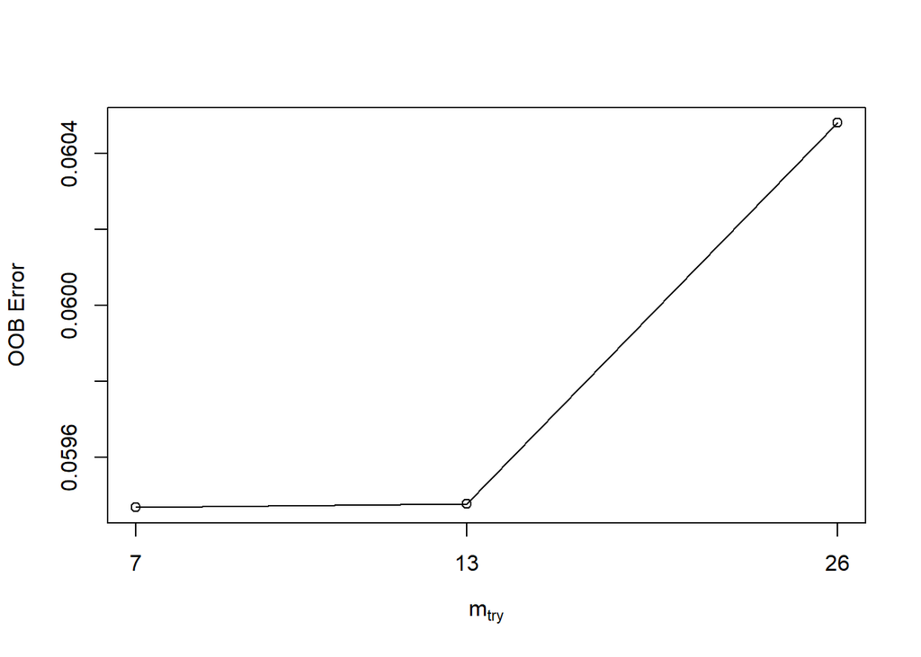

```r
t<-tuneRF(RTrain[,-32], RTrain[,32],
          stepfactor=0.5,
          plot=TRUE,
          ntreeTry=300,
          trace = TRUE,
          improve = 0.05)
```

```r
RModel<-randomForest(NPS_Status~.,data=RTrain,
                     ntree=300,
                     mtry=13,
                     importance=TRUE,
                     proximity=TRUE)
RModel
```

```
##
## Call:
##  randomForest(formula = NPS_Status ~ ., data = RTrain, ntree = 300,      mtry = 13, importance = TRUE, proximity = TRUE)
##                Type of random forest: classification
##                      Number of trees: 300
## No. of variables tried at each split: 13
##
##         OOB estimate of  error rate: 23.67%
## Confusion matrix:
##           Detractor Promotor class.error
## Detractor       990      626   0.3873762
## Promotor        388     2279   0.1454818
```

*Evaluate the model using Test data*

```r
PredictR<-predict(RModel,RTest)
```

*Confusion Matrix*

```r
confusionMatrix(PredictR,RTest$NPS_Status)
```

```
## Confusion Matrix and Statistics
##
##            Reference
## Prediction  Detractor Promotor
##   Detractor       235       97
##   Promotor        159      579
##
##                Accuracy : 0.7607
##                  95% CI : (0.734, 0.786)
##     No Information Rate : 0.6318
##     P-Value [Acc > NIR] : < 2.2e-16
##
##                   Kappa : 0.4683
##
##  Mcnemar's Test P-Value : 0.0001376
##
##             Sensitivity : 0.5964
##             Specificity : 0.8565
##          Pos Pred Value : 0.7078
##          Neg Pred Value : 0.7846
##              Prevalence : 0.3682
##          Detection Rate : 0.2196
##    Detection Prevalence : 0.3103
##       Balanced Accuracy : 0.7265
##
##        'Positive' Class : Detractor
##
```

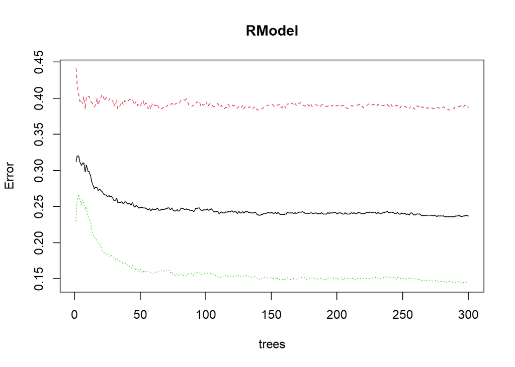

```r
plot(RModel)
```

```r
RTest$Predicted<-PredictR
RTest$Predicted_Value<-ifelse(RTest$Predicted=="Promotor",1,0)
RTest$Actual<-ifelse(RTest$NPS_Status=="Promotor",1,0)
```

*Which variable plays important role in the model*

[figure not shown]

```r
varImpPlot(RModel,
           Sort=T,
           n.var = 10,
           main = "Top 10 Important Variables")
```

*Compare ROC and AUC for Logistic Regression, Decision Tree, and Random Forest*

```r
par(pty="s")
roc(Test$Actual,Predicted, plot=TRUE, print.auc=TRUE,legacy.axes=TRUE, percent=TRUE, xlab="False Positive Percentage",
    ylab="True Positive Percentage", col="#de2d26",lwd=4)
```

```
##
## Call:
## roc.default(response = Test$Actual, predictor = Predicted, percent = TRUE,     plot = TRUE, print.auc = TRUE, legacy.axes = TRUE, xlab = "False Positive Percentage",     ylab = "True Positive Percentage", col = "#de2d26", lwd = 4)
##
## Data: Predicted in 402 controls (Test$Actual 0) < 668 cases (Test$Actual 1).
## Area under the curve: 79.6%
```

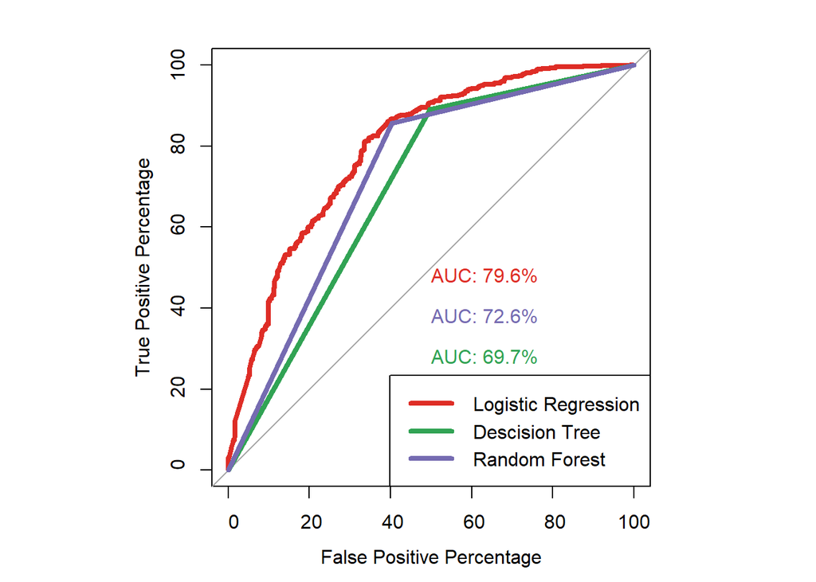

```r
plot.roc(DTest$Actual, DTest$Pre_Value, percent=TRUE, col="#31a354", lwd=4, print.auc=TRUE,add=TRUE, print.auc.y=30)
plot.roc(RTest$NPS_Status,RTest$Predicted_Value,percent=TRUE, col="#756bb1", lwd=4, print.auc=TRUE,add=TRUE, print.auc.y=40)
legend("bottomright", legend = c("Logistic Regression", "Descision Tree", "Random Forest"), col=c("#de2d26","#31a354","#756bb1"),lwd=4)
```